# Part II - (Ford GoBike Exploration Data Analysis)

## by (Muhammed Balogun)

## Investigation Overview

> In this project, I want to study how duration of bike ride depends on member gender, user type, bike share for all trip, start hour, start day, end hour and end day of ride.

## Dataset Overview

> The Ford GoBike data set contains information about individual rides made in a bike-sharing system covering the greater San Francisco Bay area. The dataset is made up of 183412 observations with 16 columns. Nine additional columns were created, bring the total columns in the dataset to 25.

> The main feature of interest is the duration_min and how other features contribute to the length of ride. The features that will help to support the main feature of interest are; start_day, end_day, start_hour, end_hour, user_type, member_gender, member_birth_year and bike_share_for_all_trip.

## Distribution of Member Gender, User Type and Bike Share for All Trip

> Most member in the dataset identify themselves as either male or female while very few members have other sex classification. It can be observed that there are more male bike riders than there are female riders.

> There are two bike user types in the dataset; Customer and Subscribers. Most of the bike users are subscribers

> Only few bike users share their ride during the whole trip.

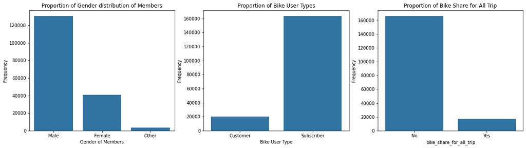

## Distribution of Duration of Ride

> Using a log scale, the distrubution of duration per seconds value was further verified to be right-skewed with majority of the users at the left part of the chart.

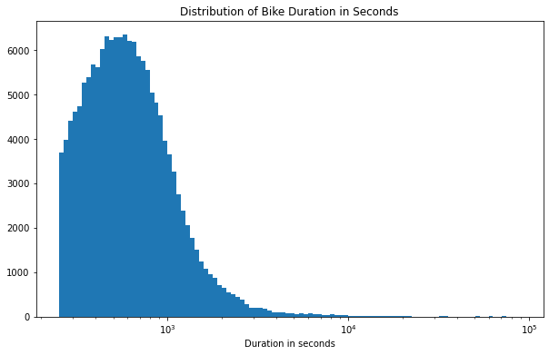

## Top Ten Start Station with The Highest Frequency

> The start station name with the highest freqency of use is the **Market St at 10th St** followed by **San Francisco Caltrain Station** and so on as it presented in the chart below.

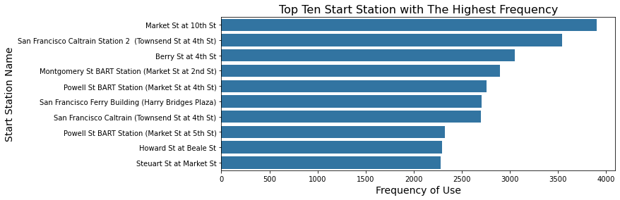

## Top Ten End Station with The Highest Frequency

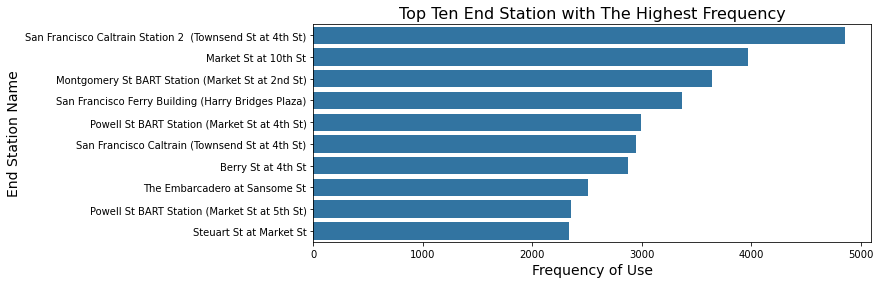

## Relationship between User Type and Ride Duration

> The median duration per minute for customers are higher than that of the subscribers, but subscribers tends to spend more time on ride than customers.

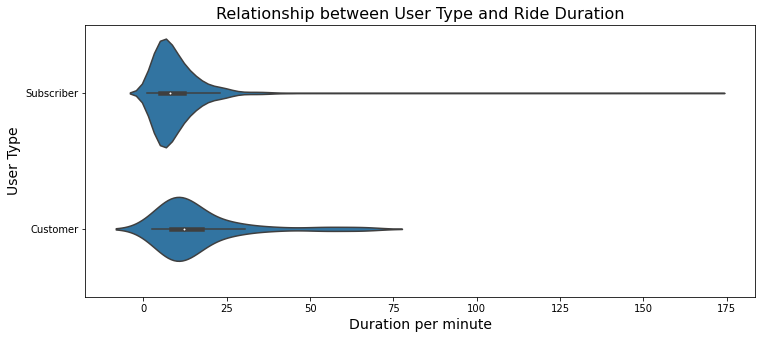

## Relationship between Gender of Members and Ride Duration

> The members with other sex have higher median duration per minute of ride out the three sex classification. However, female riders tends to spend more minutes of ride among them.

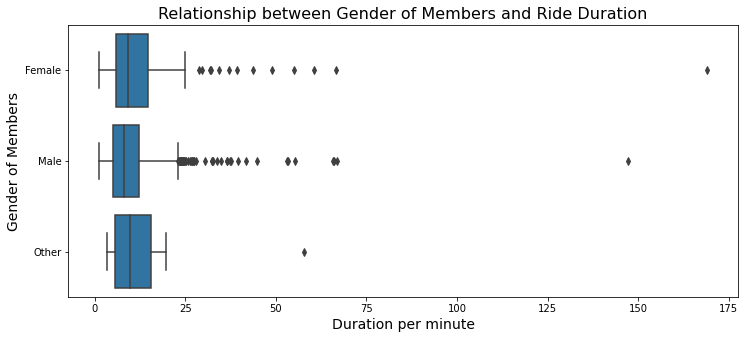

## Duration of Rides against Gender of Members and User Type

> In all the gender classification, customer user types spend more time on ride than subsciber user types. The other sex types have higher ride duration followed by the female riders. The male riders seem to spend the least time on the journey.

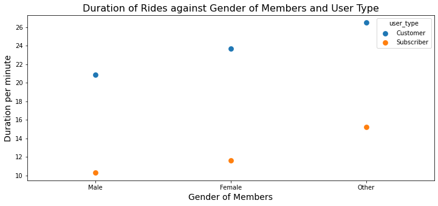

## Duration of Rides against Start Day and User Type

> The behaviour of Subscriber user types is approximately the same on each start day of ride while Customer user types spend more time on ride on Saturday and Sunday.

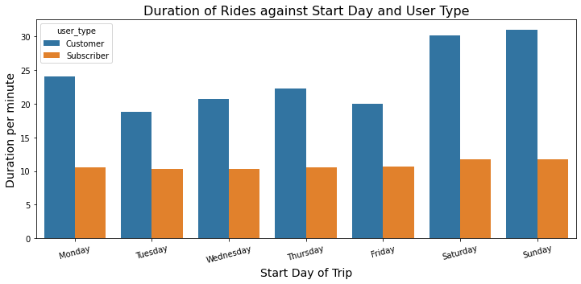